# Predicting World Happiness for year 2023 using Data Analysis

2024-04-22

# TEAM MEMBERS

1. Guruteja Kanderi
2. Alphy Benny
3. Chandini Nalamalapu

# BUSINESS CONTEXT

Understanding the dynamics of global happiness and well-being is paramount for organizations aiming to foster environments conducive to growth and prosperity. By leveraging insights from the World Happiness Report, businesses can craft strategies that prioritize employee satisfaction, societal well-being, and sustainable development. These informed decisions not only enhance workplace culture but also contribute to the creation of resilient and thriving economies on a global scale.

# PROBLEM DESCRIPTION

In our modern, interconnected world, grasping the complex tapestry of global happiness and well-being stands as a vital endeavor. The mission of the World Happiness Report is to delve deep into the realms of human satisfaction, unraveling the diverse factors that shape it. This pursuit transcends mere academic inquiry; it represents a journey to uncover the essence of human fulfillment, guiding informed policy making and precise interventions. Through the development of a predictive framework that integrates socio-economic, health, and other relevant variables, our aim is to illuminate a path toward a world that is not only happier but also more resilient. (Please note that the analysis is based on data from the year 2023.)

# DATASET DESCRIPTION

The World Happiness Report dataset consist of several variables, such as:

1. Country : The name of the country
2. Region : Region to which the country belongs
3. Ladder Score : the overall score of happiness in a country on an average from the collective responses of the people based on the factors impacting well being.
4. GDP : the gross domestic product per capita in purchasing power parity (PPP) adjusted dollars.
5. Freedom : the perceived freedom to make life choices in the country.
6. Corruption : the perceived level of corruption in the government and business sectors of the country.
7. Life Expectancy : Healthy life expectancy at birth
8. Social Support : the perceived social support (ability to count on others) in the country
9. Dystopia residual : the extent to which the country’s happiness score deviates from an imagined dystopian society with the least happy possible outcomes.
10. Generosity : the perceived generosity of people in the country.

# STEP 1: INCLUDING LIBRARIES:

```r
library(MASS)
library(tidyverse)
library(reshape2)
```

```r
library(lattice)
library(ggplot2)
library(data.table)
library(DataExplorer)
library(viridis)
library(corrplot)
library(car)
```

# STEP 2: DATA PREPARATION:

# Data Loading

```r
OriginalData <- read.csv("C:/Users/18722/Downloads/WHR2023.csv", na.strings = c('N/A'))
```

# Checking data type

```r
print(class(OriginalData))
```

```
## [1] "data.frame"
```

# Reviewing the data

```r
#Review the Original Data
OriginalData <- as.data.table(OriginalData)
OriginalData
```

| Country.name | Regional.indicator | Ladder.score | Standard.error.of.ladder.score | upperwhisker | lowerwhisker | Logged.GDP.per.capita | Social.support | Healthy.life.expectancy | Freedom.to.make.life.choices | Generosity | Perceptions.of.corruption | Ladder.score.in.Dystopia | Explained.by..Log.GDP.per.capita | Explained.by..Social.support | Explained.by..Healthy.life.expectancy | Explained.by..Freedom.to.make.life.choices | Explained.by..Generosity | Explained.by..Perceptions.of.corruption | Dystopia...residual |
| --- | --- | --- | --- | --- | --- | --- | --- | --- | --- | --- | --- | --- | --- | --- | --- | --- | --- | --- | --- |
| Finland | Western Europe | 7.804 | 0.036 | 7.875 | 7.733 | 10.792 | 0.969 | 71.150 | 0.961 | -0.019 | 0.182 | 1.778 | 1.888 | 1.585 | 0.535 | 0.772 | 0.126 | 0.535 | 2.363 |
| Denmark | Western Europe | 7.586 | 0.041 | 7.667 | 7.506 | 10.962 | 0.954 | 71.250 | 0.934 | 0.134 | 0.196 | 1.778 | 1.949 | 1.548 | 0.537 | 0.734 | 0.208 | 0.525 | 2.084 |
| Iceland | Western Europe | 7.530 | 0.049 | 7.625 | 7.434 | 10.896 | 0.983 | 72.050 | 0.936 | 0.211 | 0.668 | 1.778 | 1.926 | 1.620 | 0.559 | 0.738 | 0.250 | 0.187 | 2.250 |
| Israel | Middle East and North Africa | 7.473 | 0.032 | 7.535 | 7.411 | 10.639 | 0.943 | 72.697 | 0.809 | -0.023 | 0.708 | 1.778 | 1.833 | 1.521 | 0.577 | 0.569 | 0.124 | 0.158 | 2.691 |
| Netherlands | Western Europe | 7.403 | 0.029 | 7.460 | 7.346 | 10.942 | 0.930 | 71.550 | 0.887 | 0.213 | 0.379 | 1.778 | 1.942 | 1.488 | 0.545 | 0.672 | 0.251 | 0.394 | 2.110 |
| Sweden | Western Europe | 7.395 | 0.037 | 7.468 | 7.322 | 10.883 | 0.939 | 72.150 | 0.948 | 0.165 | 0.202 | 1.778 | 1.921 | 1.510 | 0.562 | 0.754 | 0.225 | 0.520 | 1.903 |
| Norway | Western Europe | 7.315 | 0.044 | 7.402 | 7.229 | 11.088 | 0.943 | 71.500 | 0.947 | 0.141 | 0.283 | 1.778 | 1.994 | 1.521 | 0.544 | 0.752 | 0.212 | 0.463 | 1.829 |
| Switzerland | Western Europe | 7.240 | 0.043 | 7.324 | 7.156 | 11.164 | 0.920 | 72.900 | 0.891 | 0.027 | 0.266 | 1.778 | 2.022 | 1.463 | 0.582 | 0.678 | 0.151 | 0.475 | 1.870 |
| Luxembourg | Western Europe | 7.228 | 0.069 | 7.363 | 7.093 | 11.660 | 0.879 | 71.675 | 0.915 | 0.024 | 0.345 | 1.778 | 2.200 | 1.357 | 0.549 | 0.710 | 0.149 | 0.418 | 1.845 |
| New Zealand | North America and ANZ | 7.123 | 0.038 | 7.198 | 7.048 | 10.662 | 0.952 | 70.350 | 0.887 | 0.175 | 0.271 | 1.778 | 1.842 | 1.544 | 0.513 | 0.672 | 0.230 | 0.471 | 1.852 |

[output cut: 127 more lines]

# Finding number of observations and columns in dataset

```r
dim(OriginalData)
```

```
## [1] 137  20
```

> There are 137 observations and 20 features in dataset.

# Reviewing the structure of data frame

```r
str(OriginalData)
```

```
## Classes 'data.table' and 'data.frame':   137 obs. of  20 variables:
##  $ Country.name                              : chr  "Finland" "Denmark" "Iceland" "Israel" ...
##  $ Regional.indicator                        : chr  "Western Europe" "Western Europe" "Western Europe" "Middle East and North Africa" ...
##  $ Ladder.score                              : num  7.8 7.59 7.53 7.47 7.4 ...
##  $ Standard.error.of.ladder.score            : num  0.036 0.041 0.049 0.032 0.029 0.037 0.044 0.043 0.069 0.038 ...
##  $ upperwhisker                              : num  7.88 7.67 7.62 7.54 7.46 ...
##  $ lowerwhisker                              : num  7.73 7.51 7.43 7.41 7.35 ...
##  $ Logged.GDP.per.capita                     : num  10.8 11 10.9 10.6 10.9 ...
##  $ Social.support                            : num  0.969 0.954 0.983 0.943 0.93 0.939 0.943 0.92 0.879 0.952 ...
##  $ Healthy.life.expectancy                   : num  71.2 71.2 72 72.7 71.5 ...
##  $ Freedom.to.make.life.choices              : num  0.961 0.934 0.936 0.809 0.887 0.948 0.947 0.891 0.915 0.887 ...
##  $ Generosity                                : num  -0.019 0.134 0.211 -0.023 0.213 0.165 0.141 0.027 0.024 0.175 ...
##  $ Perceptions.of.corruption                 : num  0.182 0.196 0.668 0.708 0.379 0.202 0.283 0.266 0.345 0.271 ...
##  $ Ladder.score.in.Dystopia                  : num  1.78 1.78 1.78 1.78 1.78 ...
##  $ Explained.by..Log.GDP.per.capita          : num  1.89 1.95 1.93 1.83 1.94 ...
##  $ Explained.by..Social.support              : num  1.58 1.55 1.62 1.52 1.49 ...
##  $ Explained.by..Healthy.life.expectancy     : num  0.535 0.537 0.559 0.577 0.545 0.562 0.544 0.582 0.549 0.513 ...
##  $ Explained.by..Freedom.to.make.life.choices: num  0.772 0.734 0.738 0.569 0.672 0.754 0.752 0.678 0.71 0.672 ...
##  $ Explained.by..Generosity                  : num  0.126 0.208 0.25 0.124 0.251 0.225 0.212 0.151 0.149 0.23 ...
##  $ Explained.by..Perceptions.of.corruption   : num  0.535 0.525 0.187 0.158 0.394 0.52 0.463 0.475 0.418 0.471 ...
##  $ Dystopia...residual                       : num  2.36 2.08 2.25 2.69 2.11 ...
##  - attr(*, ".internal.selfref")=<externalptr>
```

> All Columns are assigned with correct data types.

# Loading required data in data frame.

```r
data <- subset(OriginalData, select=c("Country.name",
                              "Regional.indicator",
                              "Ladder.score",
                              "Logged.GDP.per.capita",
                              "Social.support",
                              "Healthy.life.expectancy",
                              "Freedom.to.make.life.choices",
                              "Generosity",
                              "Perceptions.of.corruption",
                              "Dystopia...residual"))

data
```

| Country.name | Regional.indicator | Ladder.score | Logged.GDP.per.capita | Social.support | Healthy.life.expectancy | Freedom.to.make.life.choices | Generosity | Perceptions.of.corruption | Dystopia...residual |
| --- | --- | --- | --- | --- | --- | --- | --- | --- | --- |
| Finland | Western Europe | 7.804 | 10.792 | 0.969 | 71.150 | 0.961 | -0.019 | 0.182 | 2.363 |
| Denmark | Western Europe | 7.586 | 10.962 | 0.954 | 71.250 | 0.934 | 0.134 | 0.196 | 2.084 |
| Iceland | Western Europe | 7.530 | 10.896 | 0.983 | 72.050 | 0.936 | 0.211 | 0.668 | 2.250 |
| Israel | Middle East and North Africa | 7.473 | 10.639 | 0.943 | 72.697 | 0.809 | -0.023 | 0.708 | 2.691 |
| Netherlands | Western Europe | 7.403 | 10.942 | 0.930 | 71.550 | 0.887 | 0.213 | 0.379 | 2.110 |
| Sweden | Western Europe | 7.395 | 10.883 | 0.939 | 72.150 | 0.948 | 0.165 | 0.202 | 1.903 |
| Norway | Western Europe | 7.315 | 11.088 | 0.943 | 71.500 | 0.947 | 0.141 | 0.283 | 1.829 |
| Switzerland | Western Europe | 7.240 | 11.164 | 0.920 | 72.900 | 0.891 | 0.027 | 0.266 | 1.870 |
| Luxembourg | Western Europe | 7.228 | 11.660 | 0.879 | 71.675 | 0.915 | 0.024 | 0.345 | 1.845 |
| New Zealand | North America and ANZ | 7.123 | 10.662 | 0.952 | 70.350 | 0.887 | 0.175 | 0.271 | 1.852 |

[output cut: 127 more lines]

# Renaming the names of columns for better readability

```r
library(dplyr)
data <- data %>% rename( Country=Country.name,
                         Region=Regional.indicator,
                         Happiness_score=Ladder.score,
                         GDP=Logged.GDP.per.capita,
                         Social_support=Social.support,
                         Life_expectancy=Healthy.life.expectancy,
                         Freedom=Freedom.to.make.life.choices,
                         Corruption=Perceptions.of.corruption,
                         Dystopia_residual=Dystopia...residual)

data
```

| Country | Region | Happiness_score | GDP | Social_support | Life_expectancy | Freedom | Generosity | Corruption | Dystopia_residual |
| --- | --- | --- | --- | --- | --- | --- | --- | --- | --- |
| Finland | Western Europe | 7.804 | 10.792 | 0.969 | 71.150 | 0.961 | -0.019 | 0.182 | 2.363 |
| Denmark | Western Europe | 7.586 | 10.962 | 0.954 | 71.250 | 0.934 | 0.134 | 0.196 | 2.084 |
| Iceland | Western Europe | 7.530 | 10.896 | 0.983 | 72.050 | 0.936 | 0.211 | 0.668 | 2.250 |
| Israel | Middle East and North Africa | 7.473 | 10.639 | 0.943 | 72.697 | 0.809 | -0.023 | 0.708 | 2.691 |
| Netherlands | Western Europe | 7.403 | 10.942 | 0.930 | 71.550 | 0.887 | 0.213 | 0.379 | 2.110 |
| Sweden | Western Europe | 7.395 | 10.883 | 0.939 | 72.150 | 0.948 | 0.165 | 0.202 | 1.903 |
| Norway | Western Europe | 7.315 | 11.088 | 0.943 | 71.500 | 0.947 | 0.141 | 0.283 | 1.829 |
| Switzerland | Western Europe | 7.240 | 11.164 | 0.920 | 72.900 | 0.891 | 0.027 | 0.266 | 1.870 |
| Luxembourg | Western Europe | 7.228 | 11.660 | 0.879 | 71.675 | 0.915 | 0.024 | 0.345 | 1.845 |
| New Zealand | North America and ANZ | 7.123 | 10.662 | 0.952 | 70.350 | 0.887 | 0.175 | 0.271 | 1.852 |

[output cut: 127 more lines]

# Reviewing summary of data

```r
summary(data)
```

```
##    Country             Region          Happiness_score      GDP
##  Length:137         Length:137         Min.   :1.859   Min.   : 5.527
##  Class :character   Class :character   1st Qu.:4.724   1st Qu.: 8.591
##  Mode  :character   Mode  :character   Median :5.684   Median : 9.567
##                                        Mean   :5.540   Mean   : 9.450
##                                        3rd Qu.:6.334   3rd Qu.:10.540
##                                        Max.   :7.804   Max.   :11.660
##  Social_support   Life_expectancy    Freedom         Generosity
##  Min.   :0.3410   Min.   : 0.00   Min.   :0.3820   Min.   :-0.25400
##  1st Qu.:0.7220   1st Qu.:60.50   1st Qu.:0.7240   1st Qu.:-0.07400
##  Median :0.8270   Median :65.83   Median :0.8010   Median : 0.00100
##  Mean   :0.7991   Mean   :64.49   Mean   :0.7874   Mean   : 0.02243
##  3rd Qu.:0.8960   3rd Qu.:69.35   3rd Qu.:0.8740   3rd Qu.: 0.11700
##  Max.   :0.9830   Max.   :77.28   Max.   :0.9610   Max.   : 0.53100
##    Corruption     Dystopia_residual
##  Min.   :0.1460   Min.   :-0.110
##  1st Qu.:0.6680   1st Qu.: 1.553
##  Median :0.7740   Median : 1.845
##  Mean   :0.7254   Mean   : 1.765
##  3rd Qu.:0.8460   3rd Qu.: 2.078
##  Max.   :0.9290   Max.   : 2.955
```

# Descriptive Statistics

```r
Mean_Happiness_Score <- mean(data$Happiness_score)
Variance_Happiness_Score <- var(data$Happiness_score)
StdDev_Happiness_Score <- sd(data$Happiness_score)
Median_Happiness_Score <- median(data$Happiness_score)

cat("Mean Happiness score is ",Mean_Happiness_Score)
```

```
## Mean Happiness score is  5.539796
```

```r
cat("\nVariance of Happiness score is ",Variance_Happiness_Score)
```

```
##
## Variance of Happiness score is  1.299438
```

```r
cat("\nStandard Deviation of Happiness score is ",StdDev_Happiness_Score)
```

```
##
## Standard Deviation of Happiness score is  1.139929
```

```r
cat("\nMedian Happiness score is ",Median_Happiness_Score)
```

```
##
## Median Happiness score is  5.684
```

# STEP 3: DATA CLEANING

# Checking missing values

```r
MissingValueColumnName <- colnames(data)[colSums(is.na(data)) > 0]
NumberOfMissingValues <- sum(is.na(data))
cat("There are", NumberOfMissingValues, "Missing Values in Column name", MissingValueColumnName)
```

```
## There are 0 Missing Values in Column name
```

# Unique values in Region

```r
# Get the unique values of a Region column
unique_values <- data %>% distinct(Region)

# Print the unique values
print(unique_values)
```

```
##                          Region
##                          <char>
## 1:               Western Europe
## 2: Middle East and North Africa
## 3:        North America and ANZ
## 4:   Central and Eastern Europe
## 5:  Latin America and Caribbean
## 6:                    East Asia
## 7:               Southeast Asia
## 8:           Sub-Saharan Africa
## 9:                   South Asia
```

# Combining Multiple similar named region into one

```r
library(dplyr)
library(forcats)
# Creating data frame for unique region
dataRegion <- data
# change region to factor
dataRegion$Region <- as.factor(dataRegion$Region)
# combine south asia and southeast asia and east asia
dataRegion <- dataRegion %>% mutate(Region = fct_recode(Region,
                             # new name         old name
                             "Southeast Asia" = "South Asia",
                             "Southeast Asia" = "East Asia"))

# Get the unique values of a Region column
unique_values <- unique(dataRegion$Region)

# Print the unique values
print(unique_values)
```

```
## [1] Western Europe               Middle East and North Africa
## [3] North America and ANZ        Central and Eastern Europe
## [5] Latin America and Caribbean  Southeast Asia
## [7] Sub-Saharan Africa
## 7 Levels: Central and Eastern Europe ... Western Europe
```

# STEP 4: CHECKING NORMAL DISTRIBUTION OF TARGET VARIABLE

# 1. Checking distribution of target variable Happiness_score using Histogram as we know that target variable is a continuous variable

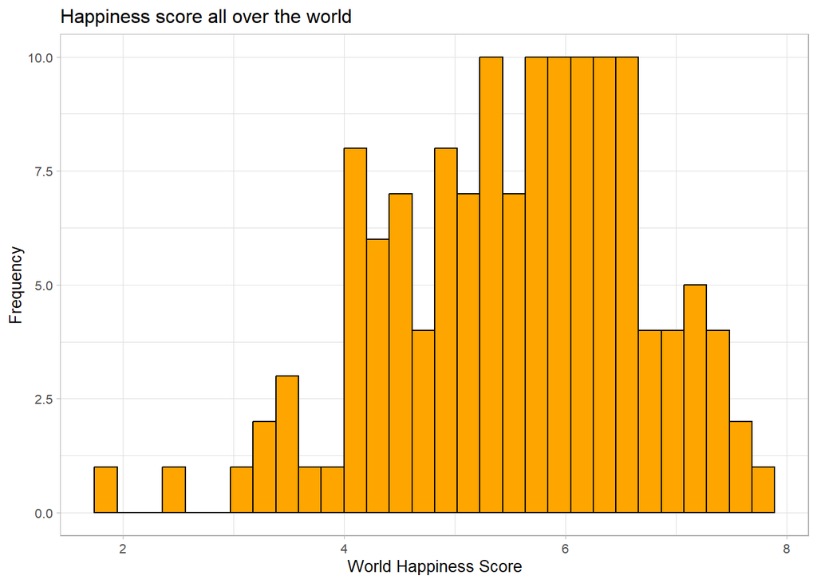

```r
library(ggplot2)
ggplot(data=data, aes(data$Happiness_score,y = after_stat(count))) +
  geom_histogram( fill = "orange", color = "black", bins = 30)+
  theme_light(base_size = 10)+
  labs(title="Happiness score all over the world", x = "World Happiness Score", y = "Frequency")
```

# 2. Plot to check normal distribution of target variable

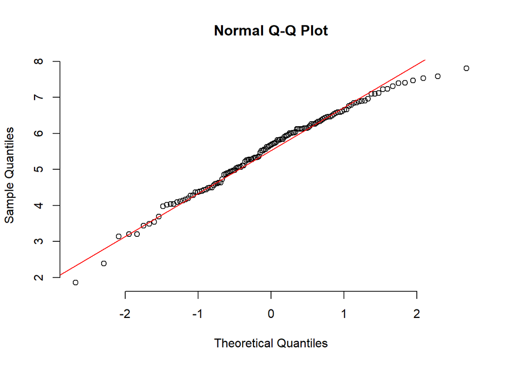

```r
qqnorm(data$Happiness_score, pch = 1, frame = FALSE)
qqline(data$Happiness_score, col = "red")
```

> In the above normal probability plot , the data points roughly follow a straight line which states that the data follows a normal distribution.